# Unit 3 Logistic Regression

Vinyas

8 May 2016

##### Reading the necessary files and their summary

```r
quality=read.csv("Data Files/quality.csv")
summary(quality)
```

```
##     MemberID     InpatientDays       ERVisits       OfficeVisits
##  Min.   :  1.0   Min.   : 0.000   Min.   : 0.000   Min.   : 0.00
##  1st Qu.: 33.5   1st Qu.: 0.000   1st Qu.: 0.000   1st Qu.: 7.00
##  Median : 66.0   Median : 0.000   Median : 1.000   Median :12.00
##  Mean   : 66.0   Mean   : 2.718   Mean   : 1.496   Mean   :13.23
##  3rd Qu.: 98.5   3rd Qu.: 3.000   3rd Qu.: 2.000   3rd Qu.:18.50
##  Max.   :131.0   Max.   :30.000   Max.   :11.000   Max.   :46.00
##    Narcotics      DaysSinceLastERVisit      Pain         TotalVisits
##  Min.   : 0.000   Min.   :  6.0        Min.   :  0.00   Min.   : 0.00
##  1st Qu.: 0.000   1st Qu.:207.0        1st Qu.:  1.00   1st Qu.: 8.00
##  Median : 1.000   Median :641.0        Median :  8.00   Median :15.00
##  Mean   : 4.573   Mean   :480.6        Mean   : 15.56   Mean   :17.44
##  3rd Qu.: 3.000   3rd Qu.:731.0        3rd Qu.: 23.00   3rd Qu.:22.50
##  Max.   :59.000   Max.   :731.0        Max.   :104.00   Max.   :69.00
##  ProviderCount   MedicalClaims      ClaimLines    StartedOnCombination
##  Min.   : 5.00   Min.   : 11.00   Min.   : 20.0   Mode :logical
##  1st Qu.:15.00   1st Qu.: 25.50   1st Qu.: 83.5   FALSE:125
##  Median :20.00   Median : 37.00   Median :120.0   TRUE :6
##  Mean   :23.98   Mean   : 43.24   Mean   :142.9   NA's :0
##  3rd Qu.:30.00   3rd Qu.: 49.50   3rd Qu.:185.0
##  Max.   :82.00   Max.   :194.00   Max.   :577.0
##  AcuteDrugGapSmall    PoorCare
##  Min.   : 0.000    Min.   :0.0000
##  1st Qu.: 0.000    1st Qu.:0.0000
##  Median : 1.000    Median :0.0000
##  Mean   : 2.695    Mean   :0.2519
##  3rd Qu.: 3.000    3rd Qu.:0.5000
##  Max.   :71.000    Max.   :1.0000
```

```r
str(quality)
```

```
## 'data.frame':    131 obs. of  14 variables:
##  $ MemberID            : int  1 2 3 4 5 6 7 8 9 10 ...
##  $ InpatientDays       : int  0 1 0 0 8 2 16 2 2 4 ...
##  $ ERVisits            : int  0 1 0 1 2 0 1 0 1 2 ...
##  $ OfficeVisits        : int  18 6 5 19 19 9 8 8 4 0 ...
##  $ Narcotics           : int  1 1 3 0 3 2 1 0 3 2 ...
##  $ DaysSinceLastERVisit: num  731 411 731 158 449 ...
##  $ Pain                : int  10 0 10 34 10 6 4 5 5 2 ...
##  $ TotalVisits         : int  18 8 5 20 29 11 25 10 7 6 ...
##  $ ProviderCount       : int  21 27 16 14 24 40 19 11 28 21 ...
##  $ MedicalClaims       : int  93 19 27 59 51 53 40 28 20 17 ...
##  $ ClaimLines          : int  222 115 148 242 204 156 261 87 98 66 ...
##  $ StartedOnCombination: logi  FALSE FALSE FALSE FALSE FALSE FALSE ...
##  $ AcuteDrugGapSmall   : int  0 1 5 0 0 4 0 0 0 0 ...
##  $ PoorCare            : int  0 0 0 0 0 1 0 0 1 0 ...
```

```r
#Loading the caTools library
library(caTools)
```

##### Randomly split data

```r
set.seed(88)
split = sample.split(quality$PoorCare, SplitRatio = 0.75)
split
```

```
##   [1]  TRUE  TRUE  TRUE  TRUE FALSE  TRUE FALSE  TRUE FALSE FALSE  TRUE
##  [12] FALSE  TRUE  TRUE  TRUE  TRUE  TRUE  TRUE  TRUE  TRUE  TRUE  TRUE
##  [23]  TRUE  TRUE FALSE  TRUE  TRUE  TRUE  TRUE FALSE FALSE FALSE FALSE
##  [34]  TRUE  TRUE  TRUE FALSE  TRUE  TRUE  TRUE FALSE FALSE  TRUE  TRUE
##  [45] FALSE  TRUE FALSE  TRUE FALSE  TRUE  TRUE FALSE FALSE  TRUE  TRUE
##  [56]  TRUE  TRUE  TRUE  TRUE  TRUE  TRUE  TRUE  TRUE  TRUE  TRUE FALSE
##  [67]  TRUE  TRUE  TRUE  TRUE FALSE  TRUE  TRUE  TRUE  TRUE  TRUE  TRUE
##  [78]  TRUE  TRUE  TRUE  TRUE  TRUE  TRUE FALSE  TRUE  TRUE  TRUE  TRUE
##  [89]  TRUE  TRUE  TRUE  TRUE  TRUE FALSE  TRUE  TRUE  TRUE  TRUE  TRUE
## [100]  TRUE  TRUE  TRUE  TRUE FALSE  TRUE  TRUE  TRUE FALSE  TRUE FALSE
## [111] FALSE  TRUE  TRUE FALSE  TRUE  TRUE  TRUE FALSE  TRUE  TRUE FALSE
## [122]  TRUE  TRUE FALSE  TRUE  TRUE FALSE  TRUE  TRUE  TRUE FALSE
```

##### Create training and testing sets

```r
qualityTrain = subset(quality, split == TRUE)
qualityTest = subset(quality, split == FALSE)
```

##### Logistic Regression Model

```r
QualityLog = glm(PoorCare ~ OfficeVisits + Narcotics, data=qualityTrain, family=binomial)

#glm = generalised linear model
#glm(dependentvar ~ indepvar1+indepvar2,data=datvar,family=binomial)
#family = binomial tells the function ot create logistic regression model

summary(QualityLog)
```

```
##
## Call:
## glm(formula = PoorCare ~ OfficeVisits + Narcotics, family = binomial,
##     data = qualityTrain)
##
## Deviance Residuals:
##      Min        1Q    Median        3Q       Max
## -2.06303  -0.63155  -0.50503  -0.09689   2.16686
##
## Coefficients:
##              Estimate Std. Error z value Pr(>|z|)
## (Intercept)  -2.64613    0.52357  -5.054 4.33e-07 ***
## OfficeVisits  0.08212    0.03055   2.688  0.00718 **
## Narcotics     0.07630    0.03205   2.381  0.01728 *
## ---
## Signif. codes:  0 '***' 0.001 '**' 0.01 '*' 0.05 '.' 0.1 ' ' 1
##
## (Dispersion parameter for binomial family taken to be 1)
##
##     Null deviance: 111.888  on 98  degrees of freedom
## Residual deviance:  89.127  on 96  degrees of freedom
## AIC: 95.127
##
## Number of Fisher Scoring iterations: 4
```

##### Make predictions and analyze on training set

```r
predictTrain = predict(QualityLog, type="response")
#type = "response" gives us probabilities
# Analyze predictions
summary(predictTrain)
```

```
##    Min. 1st Qu.  Median    Mean 3rd Qu.    Max.
## 0.06623 0.11910 0.15970 0.25250 0.26760 0.98460
```

```r
tapply(predictTrain, qualityTrain$PoorCare, mean)
```

```
##         0         1
## 0.1894512 0.4392246
```

##### Quick Question

```r
#New logistic regression model
Qlog2=glm(PoorCare~StartedOnCombination+ProviderCount,data=qualityTrain,family=binomial)
summary(Qlog2)
```

```
##
## Call:
## glm(formula = PoorCare ~ StartedOnCombination + ProviderCount,
##     family = binomial, data = qualityTrain)
##
## Deviance Residuals:
##      Min        1Q    Median        3Q       Max
## -1.61826  -0.72782  -0.64555  -0.08407   1.94662
##
## Coefficients:
##                          Estimate Std. Error z value Pr(>|z|)
## (Intercept)              -2.00097    0.55097  -3.632 0.000282 ***
## StartedOnCombinationTRUE  1.95230    1.22342   1.596 0.110541
## ProviderCount             0.03366    0.01983   1.697 0.089706 .
## ---
## Signif. codes:  0 '***' 0.001 '**' 0.01 '*' 0.05 '.' 0.1 ' ' 1
##
## (Dispersion parameter for binomial family taken to be 1)
##
##     Null deviance: 111.89  on 98  degrees of freedom
## Residual deviance: 104.37  on 96  degrees of freedom
## AIC: 110.37
##
## Number of Fisher Scoring iterations: 4
```

##### Confusion matrix for threshold of 0.5

```r
table(qualityTrain$PoorCare, predictTrain > 0.5)
```

```
##
##     FALSE TRUE
##   0    70    4
##   1    15   10
```

Sensitivity and specificity are statistical measures of the performance of a binary classification test, also known in statistics as classification function:

Sensitivity (also called the true positive rate, or the recall in some fields) measures the proportion of positives that are correctly identified as such (e.g., the percentage of sick people who are correctly identified as having the condition).

Specificity (also called the true negative rate) measures the proportion of negatives that are correctly identified as such (e.g., the percentage of healthy people who are correctly identified as not having the condition).

True positive = correctly identified

False positive = incorrectly identified

True negative = correctly rejected

False negative = incorrectly rejected

Sensitivity or true positive rate (TPR)

TPR = TruePositive / PositiveInstances = TP / (TP+FalseNegative)

Specificity (SPC) or true negative rate

SPC = TrueNegative / NegativeInstances = TN / (TN+FalsePositives)

A Receiver Operator Characteristic curve, or ROC curve, can help you decide which value of the threshold is best.

The sensitivity, or true positive rate of the model, is shown on the y-axis.

And the false positive rate, or 1 minus the specificity, is given on the x-axis.

The ROC curve always starts at the point (0, 0). This corresponds to a threshold value of 1 i.e. sensitivity = 0

The ROC curve always ends at the point (1,1), which corresponds to a threshold value of 0 i.e. false positive rate = 1

The higher the threshold, or closer to (0, 0), the higher the specificity and the lower the sensitivity. The lower the threshold, or closer to (1,1), the higher the sensitivity and lower the specificity.

A Receiver Operator Characteristic curve, or ROC curve, can help you decide which value of the threshold is best.

##### Prediction function

```r
library(ROCR)
ROCRpred = prediction(predictTrain, qualityTrain$PoorCare)

# Performance function
ROCRperf = performance(ROCRpred, "tpr", "fpr")
```

##### Add threshold labels

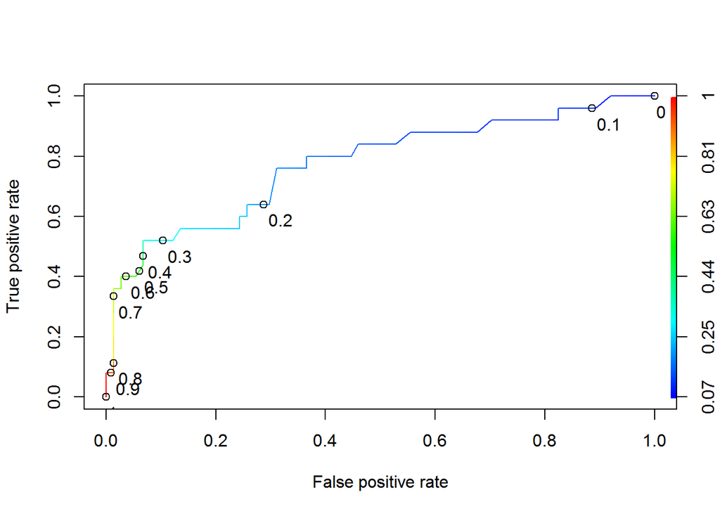

```r
plot(ROCRperf, colorize=TRUE, print.cutoffs.at=seq(0,1,by=0.1), text.adj=c(-0.2,1.7))
```

```r
###last argument in print.cutoffs sets the step value to 0.1
###what is text.adj used for ?
```